# Programmes et cours institutionnels ULaval

# Programmes et cours institutionnels ULaval

Université Laval, Bureau de la qualité des programmes

Personne à contacter**Aurélien Nicosia**Révision pédagogique et statistique

Programme actif, nouvelle activité de formation, cours accessible ou indicateur institutionnel selon le fichier source

Voir les résultats R[Source officielle](https://www.bqp.ulaval.ca/fichiers/ressources/gestion/codes-programmes-actifs.pdf)

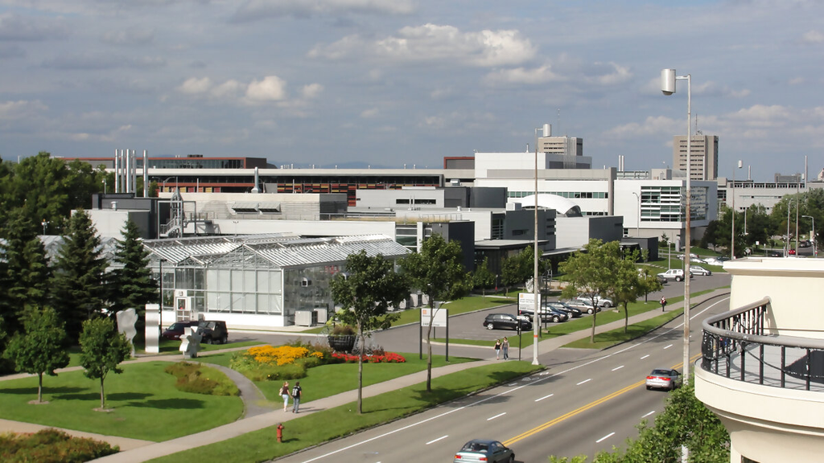

Territoire**Université Laval**

Niveau**Intermédiaire**

Structure**Tableaux institutionnels dérivés de documents publics, compilation indépendante et non officielle**

Format**CSV UTF-8 dans le dépôt privé source; seuls des résumés de validation sont publiés dans Données bleues**

Question de départ

Valider un import de données institutionnelles sans modifier les valeurs ni publier les lignes.

Potentiel pédagogique**20 / 30**

importation contrôléeprovenancevalidationdroits de réutilisationdocumentation des limitesclés uniquesdonnées privées

R en action

## Aperçu reproductible

Aperçu calculé par R à partir de data/processed/ulaval-programmes-cours/resume_ulaval_programmes_cours.csv.

Code minimal

```r
library(dplyr)

donnees <- read.csv("data/processed/ulaval-programmes-cours/resume_ulaval_programmes_cours.csv", check.names = FALSE)

glimpse(donnees)
donnees |> summarise(lignes = n(), colonnes = ncol(donnees))
```

Résultats R

Lignes lues**1**

Colonnes**18**

Variables num.**9**

Valeurs manquantes**0 %**

Aperçu**resume_ulaval_programmes_cours.csv**

| access_date | source_found | source_status | source_path_recorded | n_reference_files_expected | n_reference_files_available |
| --- | --- | --- | --- | --- | --- |
| 2026-06-21 | TRUE | source privée locale validée | chemin local privé non publié | 8 | 8 |

Lecture statistique

Pas assez de valeurs numériques pour tracer un aperçu.

Mini-projets

- Valider un import de données institutionnelles sans modifier les valeurs ni publier les lignes.
- Comparer les contrôles de clés, de provenance et de droits entre plusieurs fichiers.
- Produire une note méthodologique sur ce qui peut être montré publiquement et ce qui doit rester privé.

Activités liées

30-45 minutes**Laboratoire - Valider un import institutionnel privé**

Comment vérifier qu'un import institutionnel privé conserve les valeurs, les clés et la provenance sans publier les lignes?

2-3 heures**Mini-projet - Rapport méthodologique sans diffusion des lignes**

Comment produire un rapport utile sur une source institutionnelle privée sans créer une diffusion publique non autorisée?

## Pourquoi ce jeu est intéressant

Cette fiche documente une intégration pédagogique de données institutionnelles de l’Université Laval structurées dans un dépôt privé. Elle ne sert pas à redistribuer les lignes de données. Elle sert à enseigner comment valider un import sensible : vérifier les comptes, les clés, la provenance, les droits et les limites de publication.

Le jeu est utile parce qu’il place les étudiants et étudiantes devant une situation fréquente en science des données appliquée : les données sont utiles, structurées et vérifiables localement, mais leur republication publique n’est pas automatiquement autorisée. C’est une bonne fiche pour enseigner la différence entre source officielle, compilation indépendante, validation reproductible et diffusion publique.

Question d’analyse : comment produire une validation statistique et méthodologique utile sans publier des lignes privées ni laisser croire à une approbation officielle?

## Avertissement juridique et institutionnel

Cette intégration est une compilation indépendante et non officielle. Elle n’est pas un produit officiel ou approuvé par l’Université Laval.

Aucune licence ouverte explicite n’a été identifiée pour les données sources dans le paquet privé validé localement. Les CSV privés et les PDF sources ne sont pas redistribués dans Données bleues. Une validation institutionnelle ou juridique est nécessaire avant toute republication publique à grande échelle.

Ce document ne constitue pas un avis juridique.

## Ce qui a été vérifié

| Élément | Résultat vérifié |
| --- | --- |
| Source canonique | Dépôt GitHub privé `git@github.com:AurelienNicosiaULaval/donnees-ulaval-institutionnelles.git` |
| Source privée locale | Validée le 2026-06-21 |
| Fichiers de référence attendus | 8 |
| Fichiers de référence disponibles | 8 |
| Fichiers core validés | 3 |
| Fichiers GES validés | 3 |
| Fichier indicateurs repères inspecté | 1 |
| Lignes core validées | 1 375 |
| Lignes GES validées | 119 |
| Lignes indicateurs repères validées | 165 |
| Statut de validation core et GES | OK |
| Politique PDF | Aucun PDF source ne doit être copié dans le dépôt public |
| Statut public | Données non redistribuées; résumés de validation seulement |

## Sources officielles documentées

| Jeu | Fichier privé | Source officielle | Lignes validées |
| --- | --- | --- | --- |
| Programmes actifs | `ulaval_programmes_actifs_2026_06.csv` | Liste des codes de programmes actifs du BQP | 753 |
| Cours accessibles | `ulaval_cours_accessibles_2026_01_29.csv` | Liste des cours accessibles aux personnes étudiantes | 344 |
| Nouveaux cours | `ulaval_cours_nouveaux_2024_2025.csv` | Nouvelles activités de formation créées en 2024-2025 | 278 |
| GES portées 1 et 2 | `ulaval_ges_portees_1_2_historique.csv` | Documents institutionnels de bilan GES | 15 |
| GES bilan 2023-2024 | `ulaval_ges_bilan_2023_2024.csv` | Documents institutionnels de bilan GES | 7 |
| GES portée 3 | `ulaval_ges_portee_3_historique.csv` | Documents institutionnels de bilan GES | 97 |
| Indicateurs repères | `ulaval_indicateurs_reperes_2025.csv` | Documents institutionnels de repères et indicateurs | 165 |

Les URL et empreintes des documents sources sont conservées dans le dépôt privé, notamment dans le registre `data/sources.csv`. Elles ne sont pas reproduites ici afin d’éviter de transformer la fiche publique en mécanisme de redistribution.

## Ce que représente une ligne

| Fichier | Unité statistique |
| --- | --- |
| Programmes actifs | Un programme actif publié dans la liste institutionnelle |
| Cours accessibles | Un cours accessible aux personnes étudiantes selon le document source |
| Nouveaux cours | Une activité de formation créée pendant l’année universitaire documentée |
| GES portées 1 et 2 | Une période de bilan GES pour les portées 1 et 2 |
| GES bilan 2023-2024 | Un élément du bilan GES 2023-2024 |
| GES portée 3 | Une catégorie, période et métrique de portée 3 |
| Indicateurs repères | Un indicateur, une période et un sous-groupe |

L’unité change selon le fichier. Les analyses doivent donc rester fichier par fichier, sauf si une relation explicite est documentée.

## Variables principales

| Variable | Rôle | Point de vigilance |
| --- | --- | --- |
| `code_programme` | Clé des programmes actifs | À conserver comme chaîne de caractères |
| `programme` | Libellé du programme | Libellé source à ne pas corriger silencieusement |
| `code_cours` | Clé des fichiers de cours | À conserver comme chaîne de caractères |
| `titre` | Titre du cours | Peut servir aux contrôles de libellés, pas à une inférence |
| `faculte` | Faculté normalisée dans les nouveaux cours | Résumé descriptif local seulement |
| `credits` | Crédits des cours accessibles | Valeur numérique à ne pas modifier |
| `source_id` | Lien vers le registre des sources | Champ de provenance obligatoire |
| `page_source` | Page du PDF source | Champ essentiel pour audit reproductible |
| `note` | Note méthodologique ou source | Obligatoire dans certains fichiers complémentaires |
| `statut_quantification` | Statut des valeurs GES | Les valeurs non quantifiées ne doivent pas devenir zéro |
| `statut_valeur` | Statut des indicateurs repères | À conserver pour interpréter les valeurs |

## RÉSULTATS R

Les résultats ci-dessous proviennent de `preparation.R`, exécuté le 2026-06-21 avec `DONNEES_ULAVAL_SOURCE` pointant vers la source privée locale. Le chemin local privé n’est pas publié.

| Indicateur | Valeur |
| --- | --- |
| Source privée trouvée | Oui |
| Fichiers de référence attendus | 8 |
| Fichiers de référence disponibles | 8 |
| Jeux dans le manifeste | 7 |
| Jeux core | 3 |
| Lignes core attendues et observées | 1 375 |
| Jeux GES | 3 |
| Lignes GES attendues et observées | 119 |
| Jeux indicateurs repères | 1 |
| Lignes indicateurs repères attendues et observées | 165 |
| Validation core et GES | OK |
| Sources documentées dans `sources.csv` | 6 |

## Contrôles de validation

| Contrôle | Statut |
| --- | --- |
| Source privée | OK |
| Fichiers de référence | OK |
| Programmes actifs | OK |
| Cours accessibles | OK |
| Nouveaux cours | OK |
| GES portées 1 et 2 | OK |
| GES bilan 2023-2024 | OK |
| GES portée 3 | OK |
| Absence de PDF dans la plateforme | OK |
| Mentions de droits | OK |

Ces contrôles ne donnent pas une autorisation de republication publique. Ils indiquent que l’import local respecte les attentes connues : présence des fichiers, lignes attendues, clés uniques, champs de provenance et mentions de droits.

## Résumé des fichiers validés

| Fichier | Phase | Lignes | Colonnes | Clés uniques | Provenance présente |
| --- | --- | --- | --- | --- | --- |
| Programmes actifs | core | 753 | 11 | Oui | Oui |
| Cours accessibles | core | 344 | 11 | Oui | Oui |
| Nouveaux cours | core | 278 | 10 | Oui | Oui |
| GES portées 1 et 2 | ges | 15 | 8 | Oui | Oui |
| GES bilan 2023-2024 | ges | 7 | 8 | Oui | Oui |
| GES portée 3 | ges | 97 | 13 | Oui | Oui |
| Indicateurs repères | indicateurs | 165 | 15 | Oui | Oui |

## Ce qui peut être enseigné

Cette fiche est moins un jeu de données à explorer publiquement qu’un cas d’étude sur la responsabilité. Les apprentissages les plus importants sont :

1. conserver les codes comme chaînes de caractères;
2. valider l’unicité des clés;
3. conserver `source_id` et `page_source`;
4. distinguer validation locale et republication publique;
5. documenter les informations non vérifiées avec `Je ne sais pas.`;
6. garder les PDF sources hors du dépôt public;
7. éviter de transformer une valeur manquante ou non quantifiée en zéro.

## Score zéro déchet

| Dimension | Score | Justification |
| --- | --- | --- |
| Contexte québécois | 3 | Université Laval |
| Accessibilité pédagogique | 2 | Concepts lisibles, mais droits restrictifs |
| Qualité documentaire | 3 | Manifeste, sources, dictionnaire et validations |
| Potentiel de nettoyage | 2 | Clés, types, provenance et valeurs manquantes |
| Potentiel de visualisation | 2 | Résumés locaux possibles, non publiés comme lignes |
| Potentiel de statistique descriptive | 2 | Dénombrements utiles mais portée limitée |
| Potentiel d’inférence | 1 | Listes institutionnelles, pas un échantillon aléatoire |
| Potentiel de modélisation | 1 | Modélisation non prioritaire |
| Potentiel éthique | 3 | Droits, provenance et statut institutionnel |
| Réutilisabilité | 1 | Réutilisation publique limitée par les droits |

Total : 20 sur 30.

## Activité courte

En 30 à 45 minutes, lire les résumés de validation, identifier les clés de chaque fichier core et expliquer pourquoi les champs `source_id` et `page_source` doivent rester présents.

## Activité longue

En 2 à 3 heures, produire un rapport méthodologique local qui résume les contrôles, les droits et les limites sans publier les lignes des CSV privés.

## Code R minimal

À exécuter depuis la racine du projet. Si la source privée est absente, le script produit un résumé public indiquant que la validation locale n’a pas pu être faite.

```r
# Load libraries
library(dplyr)
library(readr)

# Optional: point to the private source before running
# Sys.setenv(DONNEES_ULAVAL_SOURCE = "/chemin/local/source-ulaval-privee")

source("datasets/ulaval-programmes-cours/preparation.R")

resume <- read_csv(
  "data/processed/ulaval-programmes-cours/resume_ulaval_programmes_cours.csv",
  show_col_types = FALSE
)

fichiers <- read_csv(
  "data/processed/ulaval-programmes-cours/resume_fichiers_ulaval.csv",
  show_col_types = FALSE
)

resume |>
  select(source_found, validation_status, n_core_expected_rows, n_ges_expected_rows)

fichiers |>
  select(dataset_id, phase, observed_rows, keys_unique, protected_fields_present)
```

## Limites et précautions

- Les CSV privés ne sont pas inclus dans le dépôt Données bleues.
- Les PDF sources ne sont pas redistribués.
- Les résumés publics ne remplacent pas le registre privé des sources.
- La source privée validée localement n’est pas un produit officiel approuvé par l’Université Laval.
- Les valeurs numériques ne doivent pas être modifiées.
- Les cellules non quantifiées, notamment en portée 3 GES, ne doivent pas être converties en zéros.
- La réutilisation publique à grande échelle exige une validation institutionnelle ou juridique. Pour cette autorisation, je ne sais pas.

## Références

- Université Laval, Bureau de la qualité des programmes. Codes de programmes actifs. Document source privé référencé dans le paquet local validé le 2026-06-21.
- Université Laval, Bureau de la qualité des programmes. Nouvelles activités de formation créées en 2024-2025. Document source privé référencé dans le paquet local validé le 2026-06-21.
- Université Laval, Bureau de la qualité des programmes. Cours accessibles aux personnes étudiantes. Document source privé référencé dans le paquet local validé le 2026-06-21.